# Практическое задание 5

1. Загрузите данные из файла `mtcars.csv`.

```r
dat <- read.csv("mtcars.csv")
```

- Для показателя «коробка передач» (столбец `am`) постройте столбчатую диаграмму. Добавьте заголовок, измените цвет всех столбцов, добавьте названия горизонтальной и вертикальной осей.

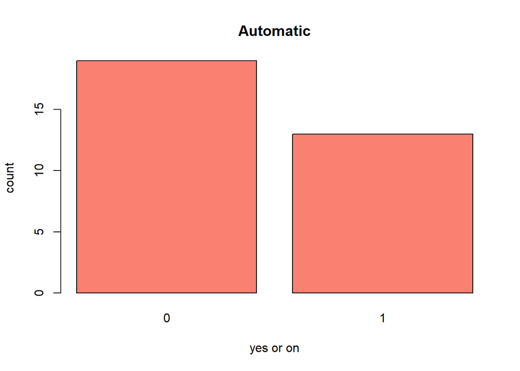

```r
barplot(table(dat$am), main = "Automatic", col = "salmon",
        xlab = "yes or on", ylab = "count"
        )
```

- Для показателя «число лошадиных сил» (столбец `hp`) постройте гистограмму. Добавьте заголовок, измените цвет заливки, добавьте подпись к горизонтальной оси.

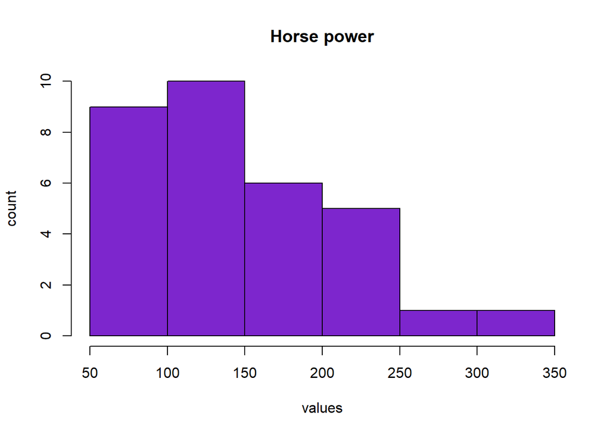

```r
hist(dat$hp, main = "Horse power", col = "purple3", xlab = "values",
     ylab = "count")
```

2. Постройте круговую диаграмму для распределения фирм по секторам из текущего урока и усовершенствуйте ее: добавьте заголовок S&P 500, поменяйте цвета так, чтобы они явно отличались друг от друга на диаграмме, вместо названий секторов на диаграмме поставьте проценты, которые каждый тип компании составляет от общего числа компаний (аргумент `labels`), а также легенду с соответствием цветов на графике секторам.

```r
dat <- read.csv("financials.csv")
```

**Подсказки:**

1. Код для создания подписей с процентами такой. Достаточно взять таблицу с частотами, которую мы уже видели, поделить все частоты в ней на сумму значений и умножить на 100:

```r
perc <- table(dat$Sector)/sum(table(dat$Sector)) * 100
perc
```

[output not shown]

Теперь мы можем округлить все значения до второго знака после запятой и доклеить к полученным значениям символ процента с помощью функции `paste()`:

```r
perc_round <- round(perc, 2)

# sep="" для того, чтобы между числами и процентами не было пробела
perc_labs <- paste(perc_round, "%", sep="")
perc_labs
```

[output not shown]

2. Вектор с названиями секторов можно получить так: `names(perc_round)`.
3. Для добавления подписей с процентами вместо названий секторов в функцию `pie()` нужно добавить аргумент `labels` и вписать туда вектор с процентами, созданный выше.

Для добавления легенды сразу после кода с самой диаграммой необходимо исполнить строку вида:

```r
legend(x=-1.2, y=-0.8, labs, cex = 0.7,
       fill = colors, ncol=3, bty="n")
```

где первые два аргумента – положение легенды на графике, `labs` – вектор с названиями секторов, `fill` – вектор используемых для заливки диаграммы цветов, `ncol` - число столбцов в легенде, `bty` – тип границы у легенды (здесь `n` - нет границы). При необходимости запросите help для функции `legend()`.

[figure not shown]

```r
perc <- table(dat$Sector)/sum(table(dat$Sector)) * 100
perc_round <- round(perc, 2)
perc_labs <- paste(perc_round, "%", sep="")

my_colors = c("red", "green", "yellow","blue", "white", "black", "orange",
              "salmon", "purple", "brown", "lightgrey")
pie(table(dat$Sector), main = "S&P 500", labels = perc_labs,
    col = my_colors)
legend(x=-1.2, y=-0.8, names(perc_round), cex = 0.7,
       fill = my_colors, ncol=3, bty="n")
```